# Response Options - further tests

2023-01-31

### Intro

We produced morphed faces of different levels of femininity and masculinity. There were 18 continua, where gender varied in seven increments, for a total of 126 faces.

There were five response options conditions:

1. binary categories - man/woman
2. multiple categories - man/woman/other/don’t know
3. Freetext - a free text box
4. binary dimension - woman ——- man on a slider
5. multiple dimensions - woman / man on separate sliders.

At the previous meeting, we decided that i would look at answering the question “do people use non-binary options when they have them?”

The way I’ve gone about doing that is by primarily comparing option the results from the multiple categories (option2) and freetext conditions (option 3).

### Do people use the beyond-binary options?

The way I went about testing that is by comparing the amount of beyond-binary (i.e. “other” and “I don’t know” responses) across the free text and multiple categories conditions. Here’s snippet of the data for some context. As you can see, I’ve translated the variable “categorization” into one called bbcat based on whether or not the answer is “o” or not.

```
## # A tibble: 6 × 4
##   categorization condition fem   bbcat
##   <chr>          <chr>     <fct> <dbl>
## 1 m              ft        0         0
## 2 m              ft        16.67     0
## 3 o              ft        33.33     1
## 4 f              ft        50        0
## 5 f              ft        66.67     0
## 6 f              ft        83.33     0
```

#### Simple explanation

So how do we actually test the question “do people use the non-binary option when they have them”? We can construct several models which gets increasingly more complicated and compare how well they predict the data.

In short, the idea is simple. We make three models:

- m0: a null model with no predictors
- m1: main effects model, with the predictors “morph level” and response option condition
- m2: interaction model, which is the the same as m1, with an additional interaction effect

### Results

Relative predictive power of models describing the outcome on the categorization task

|  | LOO difference | St. Error diff | LOO | St. Error LOO |
| --- | --- | --- | --- | --- |
| interaction | 0.00 | 0.00 | -234.17 | 23.23 |
| main_effect | -2.46 | 2.71 | -236.63 | 23.07 |
| null | -18.83 | 6.02 | -253.00 | 24.51 |

Note. LOO diff refers to the difference in loo between the model and the most predictive model. The first row describes the most predictive model, which is why the difference is 0

#### Pairwise comparisons

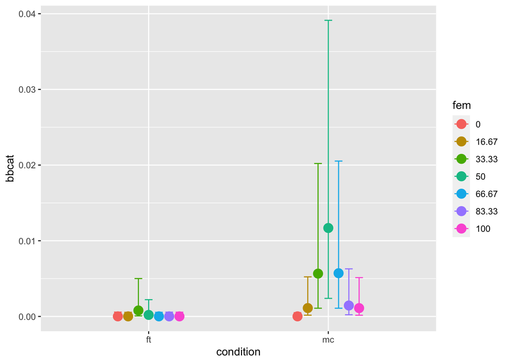

First, if we just look at the number of beyond-binary categorizations.

H1. Do particpants make beyond-binary categorizations in the multiple categories condition compared to the free text condition? It seems they do (Estimate = -4.11, CI =[-6.77], [-1.56], BF<sub>10</sub>= 61.25).

H2. If we focus on the 50/50 faces, do we still see an effect? It seems like we do (Estimate = -4.14, CI =[-7.43], [-1.4], BF<sub>10</sub>= 16.7).

H3. And if we focus on the faces at the end of the spectrum (i.e. 0 and 100 faces)? Here the evidence is only inconclusive (Estimate = -2.6, CI = [-7.96] - [2.49], BF<sub>10</sub>= 0.81). What does this mean? Well, there is an overall difference between the two conditions, and it is concentrated at the 50/50 faces

### How does this effect the relative distribution of m/f scores

Great, let’s move on to the step 2 that we talked about. So having answered the questions of “do people actually use the extra response options” with a resounding “probably, but not so much”, I’m going to move on to the second question: is it the case that the answers shift the distribution of m/f scores? What I mean is, are people replacing their ratings of “man” with ratings of “non-binary” for example. If that were to be the case, then we would expect the relative distribution of “man” scores to be somewhat lower in the multiple categories condition

Spoilers, it seems maybe not. Anyway, the first thing I did was make a version of the data where all the beyond-binary responses were taken out. Sort of the opposite of what I did last. I named the relevant variable f_cat because naming things is hard.

```
## # A tibble: 6 × 3
##   condition categorization f_cat
##   <chr>     <chr>          <dbl>
## 1 ft        m                  0
## 2 ft        m                  0
## 3 ft        o                 NA
## 4 ft        f                  1
## 5 ft        f                  1
## 6 ft        f                  1
```

I’m tired, your tired, so I’m going to move through this a little more quickly than the previous stuff. But basically, I went through the same steps as for the previous dataset, note that now I included the binary category condition this time.

We’re going to do the same thing again, we’re going to start buy looking at whether the interaction model does better than the simple effects model, and then we’re going to look at the actual effects within the model. Buuut. It doesn’t seem lik it does much here. I’m going to show all that in table 2

Relative predictive power of models describing the outcome on the categorization task

|  | LOO difference | St. Error diff | LOO | St. Error LOO |
| --- | --- | --- | --- | --- |
| morph_only | 0.00 | 0.00 | -1343.71 | 43.17 |
| main_effects | -1.85 | 0.86 | -1345.56 | 43.17 |
| condition_only | -4.98 | 5.26 | -1348.69 | 44.49 |
| Null | -5.36 | 4.88 | -1349.07 | 44.12 |
| interaction | -6.69 | 3.02 | -1350.40 | 43.48 |

Note. LOO diff refers to the difference in loo between the model and the most predictive model. The first row describes the most predictive model, which is why the difference is 0

If we start by looking at which model is the best at predicting the data, it’s clear that only the morph only model is the bast at predicting the outcome. Adding the interaction actually *decreased* prediction compared to the null model. This would be impossible with R2, which only looks at data within the sample. The risk with R2 is that you get what is known as overfitting, which is a model that is very good at predicting the pattern within the sample, but then fails outside the sample. It seems like the interaction model suffers from this problem.

Just to give a sense of what the data actually look like, I’m also going to put up a figure for the interaction between condition and morph level. This may not be good practice, but don’t tell anyone.

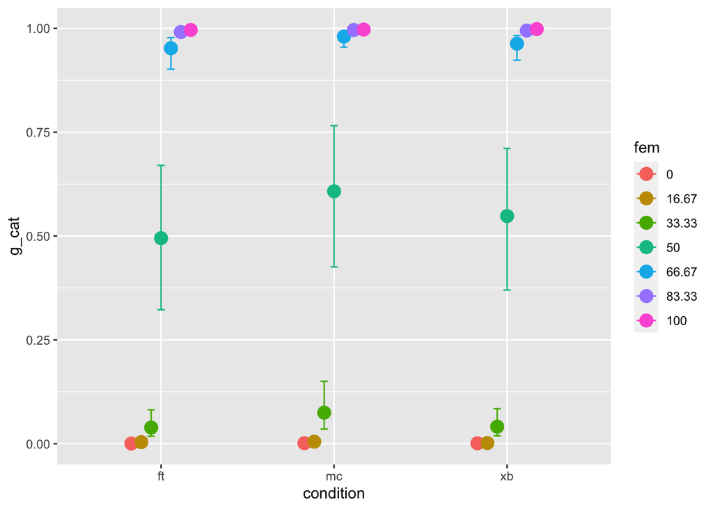

In this figure, we can see that the probability of any person answering “woman” on any face depends mostly on that face’s femininity. We can see that for 50/50 faces, this probability is veery slightly higher in the mc condition, but the results from model comparison and the fact that the confidence intervals overlap so widely make me think that this difference is pretty small.

Again, I’m out on thin ice, but just to confirm my hunch, I carried out a bayes factor on the difference between the free text and the multiple categories condition.

```
##  Family: bernoulli
##   Links: mu = logit
## Formula: g_cat ~ 0 + condition:fem + (1 | id) + (1 | face)
##    Data: tmp (Number of observations: 8368)
##   Draws: 4 chains, each with iter = 6000; warmup = 2000; thin = 1;
##          total post-warmup draws = 16000
##
## Group-Level Effects:
## ~face (Number of levels: 18)
##               Estimate Est.Error l-95% CI u-95% CI Rhat Bulk_ESS Tail_ESS
## sd(Intercept)     1.40      0.26     0.99     2.01 1.00     3492     6509
##
## ~id (Number of levels: 68)
##               Estimate Est.Error l-95% CI u-95% CI Rhat Bulk_ESS Tail_ESS
## sd(Intercept)     1.01      0.11     0.82     1.25 1.00     4595     6529
##
## Population-Level Effects:
##                      Estimate Est.Error l-95% CI u-95% CI Rhat Bulk_ESS
## conditionft:fem0        -7.75      1.25   -10.58    -5.72 1.00    10589
## conditionmc:fem0        -6.58      0.91    -8.60    -5.02 1.00     7859
## conditionxb:fem0        -6.94      0.87    -8.88    -5.43 1.00     7240
## conditionft:fem16.67    -5.58      0.61    -6.86    -4.45 1.00     4441
## conditionmc:fem16.67    -5.34      0.62    -6.63    -4.20 1.00     4987
## conditionxb:fem16.67    -6.42      0.74    -8.02    -5.09 1.00     7025
## conditionft:fem33.33    -3.21      0.40    -4.00    -2.42 1.00     2313
## conditionmc:fem33.33    -2.52      0.40    -3.31    -1.73 1.00     2415
## conditionxb:fem33.33    -3.15      0.39    -3.94    -2.39 1.00     2492
## conditionft:fem50       -0.02      0.37    -0.74     0.71 1.00     1979
## conditionmc:fem50        0.44      0.38    -0.30     1.18 1.00     2167
## conditionxb:fem50        0.19      0.36    -0.53     0.90 1.00     2156
## conditionft:fem66.67     2.99      0.40     2.22     3.77 1.00     2179
## conditionmc:fem66.67     3.91      0.45     3.04     4.81 1.00     2806
## conditionxb:fem66.67     3.26      0.40     2.49     4.03 1.00     2426
## conditionft:fem83.33     4.72      0.48     3.80     5.68 1.00     3046
## conditionmc:fem83.33     5.53      0.61     4.38     6.78 1.00     4463
## conditionxb:fem83.33     5.22      0.50     4.27     6.23 1.00     3523
## conditionft:fem100       5.55      0.58     4.46     6.75 1.00     4201
## conditionmc:fem100       5.83      0.66     4.62     7.22 1.00     5159
## conditionxb:fem100       6.33      0.65     5.12     7.69 1.00     5410
##                      Tail_ESS
```

[output cut: 10 more lines]

```
## conditionmc:fem50        4164
## conditionxb:fem50        4147
## conditionft:fem66.67     4792
## conditionmc:fem66.67     5454
## conditionxb:fem66.67     5237
## conditionft:fem83.33     5990
## conditionmc:fem83.33     7544
## conditionxb:fem83.33     6886
## conditionft:fem100       7602
## conditionmc:fem100       7760
## conditionxb:fem100       8877
##
## Draws were sampled using sampling(NUTS). For each parameter, Bulk_ESS
## and Tail_ESS are effective sample size measures, and Rhat is the potential
## scale reduction factor on split chains (at convergence, Rhat = 1).
```

The evidence were slightly in favor of there being no difference between the two conditions (Estimate = -0.46, CI =[-1.16], [0.25], BF<sub>10</sub>= 0.19).